# Лабораторная работа №11

Программирование в командном процессоре ОС UNIX. Ветвления и циклы

Рогожина Н.А.

Российский университет дружбы народов, Москва, Россия

13 апреля 2023

# Информация

## Докладчик

- Рогожина Надежда Александровна
- Студентка 1го курса, НКАбд-02-22
- Компьютерные и информационные науки
- Российский университет дружбы народов
- [Github](https://github.com/MikoGreen/study_2022-2023_os-intro)

# Вводная часть

## Актуальность

- Командный процессор (командная оболочка, интерпретатор команд shell) — это программа, позволяющая пользователю взаимодействовать с операционной системой компьютера.

## Объект и предмет исследования

- Командный процессор

## Цели и задачи

- Изучить основы программирования в оболочке ОС UNIX/Linux. Научится писать более сложные командные файлы с использованием логических управляющих конструкций и циклов.

# Задание

## Задачи:

1. Используя команды getopts grep, написать командный файл, который анализирует командную строку с ключами:
- -iinputfile — прочитать данные из указанного файла;
- -ooutputfile — вывести данные в указанный файл;
- -pшаблон — указать шаблон для поиска;
- -C — различать большие и малые буквы;
- -n — выдавать номера строк.

а затем ищет в указанном файле нужные строки, определяемые ключом -p.

## Задачи:

2. Написать на языке Си программу, которая вводит число и определяет, является ли оно больше нуля, меньше нуля или равно нулю. Затем программа завершается с помощью функции exit(n), передавая информацию в о коде завершения в оболочку. Командный файл должен вызывать эту программу и, проанализировав с помощью команды `$?`, выдать сообщение о том, какое число было введено.
3. Написать командный файл, создающий указанное число файлов, пронумерованных последовательно от 1 до 𝑁 (например 1.tmp, 2.tmp, 3.tmp,4.tmp и т.д.). Число файлов, которые необходимо создать, передаётся в аргументы командной строки. Этот же командный файл должен уметь удалять все созданные им файлы (если они существуют).
4. Написать командный файл, который с помощью команды tar запаковывает в архив все файлы в указанной директории. Модифицировать его так, чтобы запаковывались только те файлы, которые были изменены менее недели тому назад (использовать команду find).

# Содержание лабораторной работы

[figure not shown]

Скрипт №1

## Запуск первого скрипта

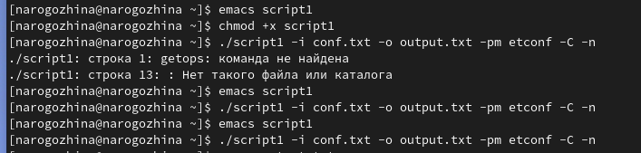

Запуск первого скрипта

## Результат

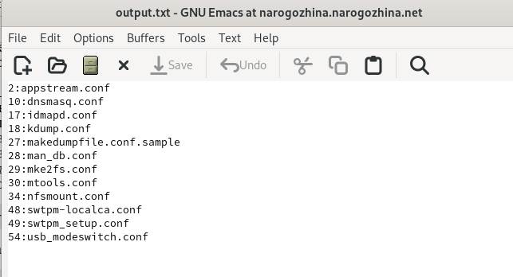

Результат

## Программа на языке С

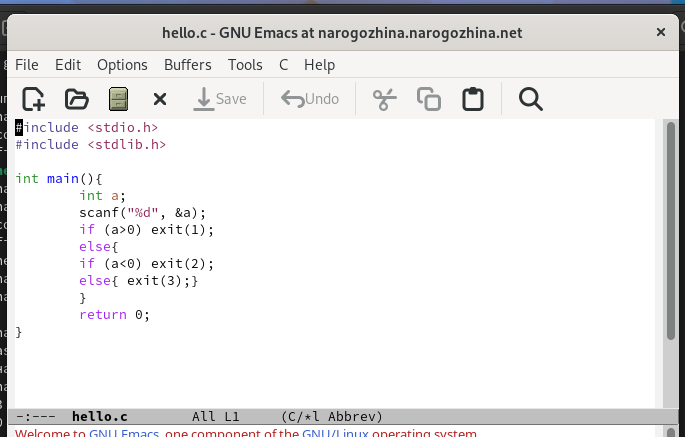

Программа на С

## Скрипт

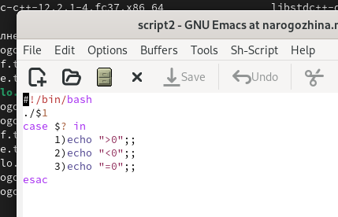

Скрипт №2

## Результат

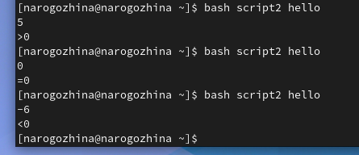

Выполнение скрипта №2

## Скрипт №3

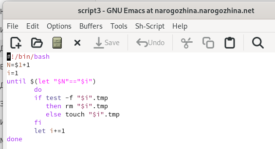

Скрипт №3

## Результат

[figure not shown]

Выполнение скрипта №3

## Выполнение повторно

[figure not shown]

Повторное выполнение скрипта №3

## Скрипт №4

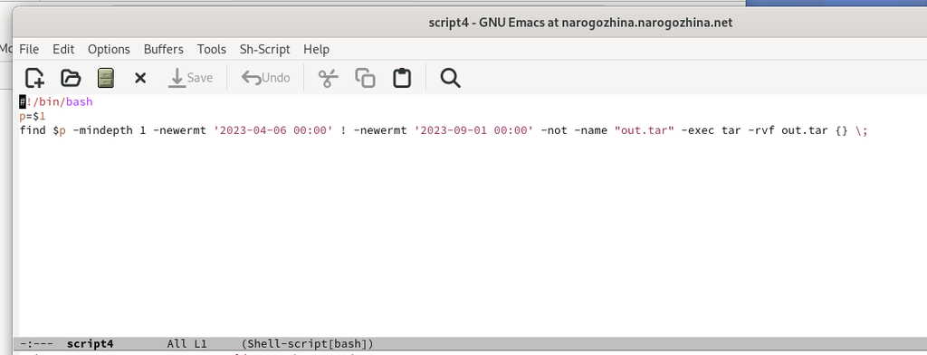

Скрипт №4

## Пример выполнения

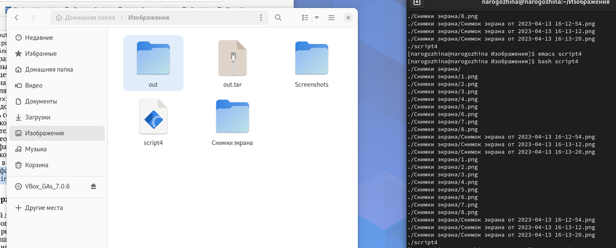

Запуск скрипта

## Результат

Здесь представлен архив out, который был создан во время работы скрипта, и в нем:

[figure not shown]

Папка out

# Выводы

## Выводы

В ходе лабораторной работы мы научились писать более сложные командные файлы с использованием логических управляющих конструкций и циклов.